# Project: Identify Customer Segments

### Discussion 3.1: Apply Clustering to General Population

**My personal Recap**

From a toy dataset (=30% of the overall data) I calculated the elbow plot, which shows the prediction score over the number of clusters. I expected to see a clear elbow bend, but I didn't. I think this is because of the small portion of data in the toy dataset. Nevertheless, I decided to go with 14 clusters.

### Step 3.2: Apply All Steps to the Customer Data

Now that you have clusters and cluster centers for the general population, it's time to see how the customer data maps on to those clusters. Take care to not confuse this for re-fitting all of the models to the customer data. Instead, you're going to use the fits from the general population to clean, transform, and cluster the customer data. In the last step of the project, you will interpret how the general population fits apply to the customer data.

- Don't forget when loading in the customers data, that it is semicolon (`;`) delimited.
- Apply the same feature wrangling, selection, and engineering steps to the customer demographics using the `clean_data()` function you created earlier. (You can assume that the customer demographics data has similar meaning behind missing data patterns as the general demographics data.)
- Use the sklearn objects from the general demographics data, and apply their transformations to the customers data. That is, you should not be using a `.fit()` or `.fit_transform()` method to re-fit the old objects, nor should you be creating new sklearn objects! Carry the data through the feature scaling, PCA, and clustering steps, obtaining cluster assignments for all of the data in the customer demographics data.

```python
# Load in the customer demographics data.
customers = pd.read_csv('Udacity_CUSTOMERS_Subset.csv', sep=';')
```

```python
customers.head()
```

|  | AGER_TYP | ALTERSKATEGORIE_GROB | ANREDE_KZ | CJT_GESAMTTYP | FINANZ_MINIMALIST | FINANZ_SPARER | FINANZ_VORSORGER | FINANZ_ANLEGER | FINANZ_UNAUFFAELLIGER | FINANZ_HAUSBAUER | ... | PLZ8_ANTG1 | PLZ8_ANTG2 | PLZ8_ANTG3 | PLZ8_ANTG4 | PLZ8_BAUMAX | PLZ8_HHZ | PLZ8_GBZ | ARBEIT | ORTSGR_KLS9 | RELAT_AB |
| --- | --- | --- | --- | --- | --- | --- | --- | --- | --- | --- | --- | --- | --- | --- | --- | --- | --- | --- | --- | --- | --- |
| 0 | 2 | 4 | 1 | 5.0 | 5 | 1 | 5 | 1 | 2 | 2 | ... | 3.0 | 3.0 | 1.0 | 0.0 | 1.0 | 5.0 | 5.0 | 1.0 | 2.0 | 1.0 |
| 1 | -1 | 4 | 1 | NaN | 5 | 1 | 5 | 1 | 3 | 2 | ... | NaN | NaN | NaN | NaN | NaN | NaN | NaN | NaN | NaN | NaN |
| 2 | -1 | 4 | 2 | 2.0 | 5 | 1 | 5 | 1 | 4 | 4 | ... | 2.0 | 3.0 | 3.0 | 1.0 | 3.0 | 3.0 | 2.0 | 3.0 | 5.0 | 3.0 |
| 3 | 1 | 4 | 1 | 2.0 | 5 | 1 | 5 | 2 | 1 | 2 | ... | 3.0 | 2.0 | 1.0 | 0.0 | 1.0 | 3.0 | 4.0 | 1.0 | 3.0 | 1.0 |
| 4 | -1 | 3 | 1 | 6.0 | 3 | 1 | 4 | 4 | 5 | 2 | ... | 2.0 | 4.0 | 2.0 | 1.0 | 2.0 | 3.0 | 3.0 | 3.0 | 5.0 | 1.0 |

5 rows × 85 columns

```python
# Apply preprocessing, feature transformation, and clustering from the general
# demographics onto the customer data, obtaining cluster predictions for the
# customer demographics data.

customers_cleaned = clean_data(customers)
```

```
Loading feature summary...
Converting missing value codes into NaNs...
Removing selected columns...
Removing rows with excessive missing data...
Re-encoding non-numeric features...
Engineering new features...
Dropping irrelevant mixed features...
Data cleaning complete.
```

```python
customers_cleaned.shape
```

```
(135799, 128)
```

```python
customers_cleaned.head()
```

|  | ALTERSKATEGORIE_GROB | ANREDE_KZ | CJT_GESAMTTYP | FINANZ_MINIMALIST | FINANZ_SPARER | FINANZ_VORSORGER | FINANZ_ANLEGER | FINANZ_UNAUFFAELLIGER | FINANZ_HAUSBAUER | FINANZTYP | ... | CAMEO_DEU_2015_8D | CAMEO_DEU_2015_9A | CAMEO_DEU_2015_9B | CAMEO_DEU_2015_9C | CAMEO_DEU_2015_9D | CAMEO_DEU_2015_9E | DECADE | MOVEMENT | WEALTH_LEVEL | LIFE_STAGE |
| --- | --- | --- | --- | --- | --- | --- | --- | --- | --- | --- | --- | --- | --- | --- | --- | --- | --- | --- | --- | --- | --- |
| 0 | 4.0 | 1 | 5.0 | 5 | 1 | 5 | 1 | 2 | 2 | 2 | ... | 0 | 0 | 0 | 0 | 0 | 0 | 1.0 | 1.0 | 1.0 | 3.0 |
| 2 | 4.0 | 2 | 2.0 | 5 | 1 | 5 | 1 | 4 | 4 | 2 | ... | 0 | 0 | 0 | 0 | 0 | 0 | 1.0 | 1.0 | 3.0 | 4.0 |
| 3 | 4.0 | 1 | 2.0 | 5 | 1 | 5 | 2 | 1 | 2 | 6 | ... | 0 | 0 | 0 | 0 | 0 | 0 | 0.0 | 0.0 | 2.0 | 4.0 |
| 4 | 3.0 | 1 | 6.0 | 3 | 1 | 4 | 4 | 5 | 2 | 2 | ... | 0 | 0 | 0 | 0 | 0 | 0 | 3.0 | 0.0 | 4.0 | 1.0 |
| 5 | 3.0 | 1 | 4.0 | 5 | 1 | 5 | 1 | 2 | 3 | 5 | ... | 0 | 0 | 0 | 0 | 0 | 0 | 1.0 | 1.0 | 3.0 | 4.0 |

5 rows × 128 columns

```python
customers_cleaned.describe()
```

|  | ALTERSKATEGORIE_GROB | ANREDE_KZ | CJT_GESAMTTYP | FINANZ_MINIMALIST | FINANZ_SPARER | FINANZ_VORSORGER | FINANZ_ANLEGER | FINANZ_UNAUFFAELLIGER | FINANZ_HAUSBAUER | FINANZTYP | ... | CAMEO_DEU_2015_8D | CAMEO_DEU_2015_9A | CAMEO_DEU_2015_9B | CAMEO_DEU_2015_9C | CAMEO_DEU_2015_9D | CAMEO_DEU_2015_9E | DECADE | MOVEMENT | WEALTH_LEVEL | LIFE_STAGE |
| --- | --- | --- | --- | --- | --- | --- | --- | --- | --- | --- | --- | --- | --- | --- | --- | --- | --- | --- | --- | --- | --- |
| count | 135595.000000 | 135799.000000 | 135799.000000 | 135799.000000 | 135799.000000 | 135799.000000 | 135799.000000 | 135799.000000 | 135799.000000 | 135799.000000 | ... | 135799.000000 | 135799.000000 | 135799.000000 | 135799.000000 | 135799.000000 | 135799.000000 | 134952.000000 | 134952.000000 | 135587.000000 | 135587.000000 |
| mean | 3.495158 | 1.329259 | 3.024742 | 4.271129 | 1.421189 | 4.572420 | 1.595711 | 1.843143 | 2.741081 | 4.235215 | ... | 0.015611 | 0.007275 | 0.006495 | 0.006944 | 0.013888 | 0.010228 | 1.873711 | 0.505409 | 2.594445 | 3.372196 |
| std | 0.721809 | 0.469946 | 1.508653 | 1.014847 | 0.823109 | 0.837007 | 0.996864 | 0.963157 | 1.313509 | 1.719058 | ... | 0.123967 | 0.084986 | 0.080329 | 0.083042 | 0.117027 | 0.100617 | 1.341251 | 0.499973 | 1.405470 | 1.338403 |
| min | 1.000000 | 1.000000 | 1.000000 | 1.000000 | 1.000000 | 1.000000 | 1.000000 | 1.000000 | 1.000000 | 1.000000 | ... | 0.000000 | 0.000000 | 0.000000 | 0.000000 | 0.000000 | 0.000000 | 0.000000 | 0.000000 | 1.000000 | 1.000000 |
| 25% | 3.000000 | 1.000000 | 2.000000 | 4.000000 | 1.000000 | 4.000000 | 1.000000 | 1.000000 | 2.000000 | 2.000000 | ... | 0.000000 | 0.000000 | 0.000000 | 0.000000 | 0.000000 | 0.000000 | 1.000000 | 0.000000 | 1.000000 | 2.000000 |
| 50% | 4.000000 | 1.000000 | 3.000000 | 5.000000 | 1.000000 | 5.000000 | 1.000000 | 2.000000 | 2.000000 | 5.000000 | ... | 0.000000 | 0.000000 | 0.000000 | 0.000000 | 0.000000 | 0.000000 | 2.000000 | 1.000000 | 2.000000 | 4.000000 |
| 75% | 4.000000 | 2.000000 | 4.000000 | 5.000000 | 2.000000 | 5.000000 | 2.000000 | 2.000000 | 4.000000 | 6.000000 | ... | 0.000000 | 0.000000 | 0.000000 | 0.000000 | 0.000000 | 0.000000 | 3.000000 | 1.000000 | 4.000000 | 4.000000 |
| max | 4.000000 | 2.000000 | 6.000000 | 5.000000 | 5.000000 | 5.000000 | 5.000000 | 5.000000 | 5.000000 | 6.000000 | ... | 1.000000 | 1.000000 | 1.000000 | 1.000000 | 1.000000 | 1.000000 | 5.000000 | 1.000000 | 5.000000 | 5.000000 |

8 rows × 128 columns

```python
with tqdm(total=2, desc="Processing") as pbar:
    customers_cleaned_imputed = impute_data(customers_cleaned)
    pbar.update(1)

    customers_cleaned_imputed_scaled, customer_scaler = scale_data(customers_cleaned_imputed)
    pbar.update(1)
```

```python
print("Shape of the dataframe:", customers_cleaned_imputed_scaled.shape)
```

```
Shape of the dataframe: (135799, 128)
```

```python
check_nan_values(customers_cleaned_imputed_scaled)
```

```
No NaN values found in the dataframe.
```

```python
customers_pca_transformed = transform_data_with_pca(pca_n, customers_cleaned_imputed_scaled)

# Convert the transformed data back to a DataFrame
customers_pca_transformed_df = pd.DataFrame(
    customers_pca_transformed,
    columns=[f"PC{i+1}" for i in range(customers_pca_transformed.shape[1])]
)
```

```python
customer_clusters, customer_kmeans_model = fit_kmeans(customers_pca_transformed_df, optimal_clusters)
```

### Step 3.3: Compare Customer Data to Demographics Data

At this point, you have clustered data based on demographics of the general population of Germany, and seen how the customer data for a mail-order sales company maps onto those demographic clusters. In this final substep, you will compare the two cluster distributions to see where the strongest customer base for the company is.

Consider the proportion of persons in each cluster for the general population, and the proportions for the customers. If we think the company's customer base to be universal, then the cluster assignment proportions should be fairly similar between the two. If there are only particular segments of the population that are interested in the company's products, then we should see a mismatch from one to the other. If there is a higher proportion of persons in a cluster for the customer data compared to the general population (e.g. 5% of persons are assigned to a cluster for the general population, but 15% of the customer data is closest to that cluster's centroid) then that suggests the people in that cluster to be a target audience for the company. On the other hand, the proportion of the data in a cluster being larger in the general population than the customer data (e.g. only 2% of customers closest to a population centroid that captures 6% of the data) suggests that group of persons to be outside of the target demographics.

Take a look at the following points in this step:

- Compute the proportion of data points in each cluster for the general population and the customer data. Visualizations will be useful here: both for the individual dataset proportions, but also to visualize the ratios in cluster representation between groups. Seaborn's [`countplot()`](https://seaborn.pydata.org/generated/seaborn.countplot.html) or [`barplot()`](https://seaborn.pydata.org/generated/seaborn.barplot.html) function could be handy.
  - Recall the analysis you performed in step 1.1.3 of the project, where you separated out certain data points from the dataset if they had more than a specified threshold of missing values. If you found that this group was qualitatively different from the main bulk of the data, you should treat this as an additional data cluster in this analysis. Make sure that you account for the number of data points in this subset, for both the general population and customer datasets, when making your computations!
- Which cluster or clusters are overrepresented in the customer dataset compared to the general population? Select at least one such cluster and infer what kind of people might be represented by that cluster. Use the principal component interpretations from step 2.3 or look at additional components to help you make this inference. Alternatively, you can use the `.inverse_transform()` method of the PCA and StandardScaler objects to transform centroids back to the original data space and interpret the retrieved values directly.
- Perform a similar investigation for the underrepresented clusters. Which cluster or clusters are underrepresented in the customer dataset compared to the general population, and what kinds of people are typified by these clusters?

```python
# Compare the proportion of data in each cluster for the customer data to the
# proportion of data in each cluster for the general population.

def plot_cluster_proportions(general_labels: np.ndarray, customer_labels: np.ndarray) -> None:
    """
    Plot the proportions of data points in each cluster for the general population and customer data.

    Args:
    - general_labels (np.ndarray): Cluster labels for the general population.
    - customer_labels (np.ndarray): Cluster labels for the customer data.
    """
    # Compute proportions for general population
    general_counts = pd.Series(general_labels).value_counts(normalize=True).sort_index()

    # Compute proportions for customer data
    customer_counts = pd.Series(customer_labels).value_counts(normalize=True).sort_index()

    # Create a DataFrame for easy plotting
    df = pd.DataFrame({
        'General Population': general_counts,
        'Customer Data': customer_counts
    }).reset_index().rename(columns={'index': 'Cluster'})

    # Plot
    plt.figure(figsize=(12, 7))

    sns.barplot(x='Cluster', y='General Population', data=df, label='General Population', color='blue', alpha=0.7)
    sns.barplot(x='Cluster', y='Customer Data', data=df, label='Customer Data', color='red', alpha=0.5)

    plt.ylabel('Proportion of Data Points')
    plt.title('Proportion of Data Points in Each Cluster')
    plt.legend()
    plt.show()
```

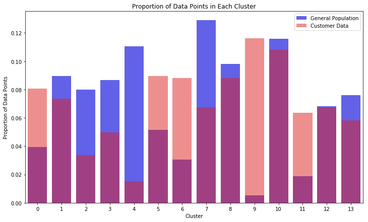

```python
# cluster_predictions = cluster predictions for general population
# customer_clusters = cluster predictions for customer data
plot_cluster_proportions(cluster_predictions, customer_clusters)
```

NOTE:

- When there is a lot of blue in a bar: that means that customers are underrepresented in this cluster and the company shouldn't focus on them.
- When there is a lot of rose in a bar: then the customers are overrepresented in this cluster, and form a target group for the company.

```python
# What kinds of people are part of a cluster that is overrepresented in the
# customer data compared to the general population?

cluster_overrepresented = 9

centroid_o = customer_kmeans_model.cluster_centers_[cluster_overrepresented]
centroid_o_df = pd.DataFrame(centroid_o,columns=['pca_weights'])
```

```python
centroid_o_df.head()
```

|  | pca_weights |
| --- | --- |
| 0 | -1.585395 |
| 1 | 1.640511 |
| 2 | -3.181166 |
| 3 | 0.514148 |
| 4 | -0.313491 |

```python
data = customer_scaler.inverse_transform(
    pca_n.inverse_transform(
        customers_pca_transformed[np.where(customer_clusters == cluster_overrepresented)]
    )
).round()

df = pd.DataFrame(
    data=data, index=np.array(range(0, data.shape[0])), columns=customers_cleaned.columns
)

df.head(10)
```

|  | ALTERSKATEGORIE_GROB | ANREDE_KZ | CJT_GESAMTTYP | FINANZ_MINIMALIST | FINANZ_SPARER | FINANZ_VORSORGER | FINANZ_ANLEGER | FINANZ_UNAUFFAELLIGER | FINANZ_HAUSBAUER | FINANZTYP | ... | CAMEO_DEU_2015_8D | CAMEO_DEU_2015_9A | CAMEO_DEU_2015_9B | CAMEO_DEU_2015_9C | CAMEO_DEU_2015_9D | CAMEO_DEU_2015_9E | DECADE | MOVEMENT | WEALTH_LEVEL | LIFE_STAGE |
| --- | --- | --- | --- | --- | --- | --- | --- | --- | --- | --- | --- | --- | --- | --- | --- | --- | --- | --- | --- | --- | --- |
| 0 | 4.0 | 2.0 | 4.0 | 3.0 | 2.0 | 4.0 | 3.0 | 3.0 | 4.0 | 2.0 | ... | -0.0 | -0.0 | -0.0 | 0.0 | 0.0 | -0.0 | 3.0 | 0.0 | 2.0 | 4.0 |
| 1 | 4.0 | 2.0 | 1.0 | 4.0 | 1.0 | 5.0 | 2.0 | 1.0 | 3.0 | 3.0 | ... | -0.0 | 0.0 | 0.0 | -0.0 | -0.0 | 0.0 | 1.0 | 0.0 | 2.0 | 5.0 |
| 2 | 4.0 | 2.0 | 3.0 | 4.0 | 1.0 | 5.0 | 1.0 | 2.0 | 3.0 | 4.0 | ... | 0.0 | -0.0 | -0.0 | -0.0 | 0.0 | -0.0 | 1.0 | 1.0 | 2.0 | 4.0 |
| 3 | 4.0 | 2.0 | 2.0 | 5.0 | 1.0 | 5.0 | 1.0 | 1.0 | 3.0 | 4.0 | ... | -0.0 | -0.0 | -0.0 | 0.0 | -0.0 | 0.0 | 1.0 | 1.0 | 1.0 | 4.0 |
| 4 | 4.0 | 2.0 | 4.0 | 4.0 | 1.0 | 5.0 | 1.0 | 2.0 | 3.0 | 4.0 | ... | 0.0 | -0.0 | 0.0 | -0.0 | 0.0 | -0.0 | 2.0 | 1.0 | 2.0 | 4.0 |
| 5 | 4.0 | 2.0 | 1.0 | 4.0 | 1.0 | 5.0 | 1.0 | 2.0 | 5.0 | 3.0 | ... | 0.0 | 0.0 | -0.0 | -0.0 | 0.0 | 0.0 | 1.0 | 1.0 | 2.0 | 5.0 |
| 6 | 3.0 | 2.0 | 3.0 | 3.0 | 2.0 | 3.0 | 4.0 | 2.0 | 4.0 | 5.0 | ... | -0.0 | 0.0 | 0.0 | -0.0 | -0.0 | 0.0 | 3.0 | -0.0 | 1.0 | 3.0 |
| 7 | 3.0 | 2.0 | 4.0 | 2.0 | 2.0 | 4.0 | 2.0 | 3.0 | 4.0 | 2.0 | ... | 0.0 | -0.0 | 0.0 | 0.0 | 0.0 | 0.0 | 4.0 | 1.0 | 2.0 | 4.0 |
| 8 | 4.0 | 2.0 | 2.0 | 5.0 | 1.0 | 4.0 | 2.0 | 1.0 | 3.0 | 5.0 | ... | 0.0 | -0.0 | -0.0 | -0.0 | 0.0 | 0.0 | 1.0 | 1.0 | 2.0 | 5.0 |
| 9 | 3.0 | 2.0 | 5.0 | 4.0 | 1.0 | 5.0 | 2.0 | 2.0 | 3.0 | 4.0 | ... | 0.0 | 0.0 | -0.0 | -0.0 | 0.0 | 0.0 | 2.0 | 0.0 | 2.0 | 4.0 |

10 rows × 128 columns

```python
def plot_scaled_comparison(df_sample, kmeans, cluster):
    """
    Performs the PCA inverse_transform of a selected cluster from our trained model to obtain
    the scaled feature weights. This helps us interpret who belongs in a given cluster.
    """
    X = (
        pd.DataFrame.from_dict(
            dict(
                zip(
                    df_sample.columns,
                    pca_n.inverse_transform(kmeans.cluster_centers_[cluster]),
                )
            ),
            orient="index",
        )
        .rename(columns={0: "feature_values"})
        .sort_values("feature_values", ascending=False)
    )
    X["feature_values_abs"] = abs(X["feature_values"])
    pd.concat(
        (X["feature_values"][:10], X["feature_values"][-10:]), axis=0
    ).plot(kind="barh")
```

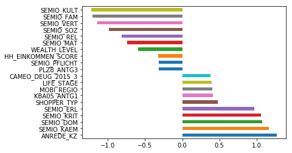

```python
plot_scaled_comparison(customers_cleaned_imputed_scaled, customer_kmeans_model, cluster_overrepresented)
```

**Observation:**

"Aggressive" (combative attitude, dominant-minded, critical-minded) people dominate this cluster. Social people have negative impact on this cluster. Hm, I wonder if they are really an attractive target audience for the company.

```python
# What kinds of people are part of a cluster that is underrepresented in the
# customer data compared to the general population?

cluster_underrepresented = 4

centroid_u = customer_kmeans_model.cluster_centers_[cluster_underrepresented]
centroid_u_df = pd.DataFrame(centroid_u,columns=['pca_weights'])
```

```python
centroid_u_df.head()
```

|  | pca_weights |
| --- | --- |
| 0 | -0.936404 |
| 1 | 0.010086 |
| 2 | 0.106363 |
| 3 | 0.340450 |
| 4 | -0.255793 |

```python
data = customer_scaler.inverse_transform(
    pca_n.inverse_transform(
        customers_pca_transformed[np.where(customer_clusters==cluster_underrepresented)]
    )
).round()
df_u = pd.DataFrame(
    data=data,
    index=np.array(range(0, data.shape[0])),
    columns=customers_cleaned.columns
)
df_u.head(10)
```

|  | ALTERSKATEGORIE_GROB | ANREDE_KZ | CJT_GESAMTTYP | FINANZ_MINIMALIST | FINANZ_SPARER | FINANZ_VORSORGER | FINANZ_ANLEGER | FINANZ_UNAUFFAELLIGER | FINANZ_HAUSBAUER | FINANZTYP | ... | CAMEO_DEU_2015_8D | CAMEO_DEU_2015_9A | CAMEO_DEU_2015_9B | CAMEO_DEU_2015_9C | CAMEO_DEU_2015_9D | CAMEO_DEU_2015_9E | DECADE | MOVEMENT | WEALTH_LEVEL | LIFE_STAGE |
| --- | --- | --- | --- | --- | --- | --- | --- | --- | --- | --- | --- | --- | --- | --- | --- | --- | --- | --- | --- | --- | --- |
| 0 | 3.0 | 1.0 | 1.0 | 5.0 | 1.0 | 4.0 | 1.0 | 2.0 | 1.0 | 5.0 | ... | -0.0 | 0.0 | 0.0 | -0.0 | -0.0 | 0.0 | 2.0 | 1.0 | 2.0 | 4.0 |
| 1 | 4.0 | 2.0 | 3.0 | 4.0 | 1.0 | 5.0 | 2.0 | 2.0 | 3.0 | 3.0 | ... | -0.0 | 0.0 | -0.0 | -0.0 | 0.0 | -0.0 | 2.0 | 1.0 | 2.0 | 4.0 |
| 2 | 4.0 | 1.0 | 4.0 | 4.0 | 2.0 | 5.0 | 2.0 | 2.0 | 2.0 | 4.0 | ... | 0.0 | -0.0 | -0.0 | -0.0 | 0.0 | -0.0 | 2.0 | 0.0 | 2.0 | 4.0 |
| 3 | 3.0 | 1.0 | 5.0 | 5.0 | 1.0 | 5.0 | 1.0 | 1.0 | 1.0 | 6.0 | ... | 0.0 | 0.0 | -0.0 | -0.0 | 0.0 | -0.0 | 2.0 | 1.0 | 2.0 | 4.0 |
| 4 | 4.0 | 2.0 | 3.0 | 4.0 | 1.0 | 5.0 | 1.0 | 1.0 | 3.0 | 4.0 | ... | -0.0 | 0.0 | -0.0 | -0.0 | 0.0 | 0.0 | 1.0 | 1.0 | 2.0 | 4.0 |
| 5 | 4.0 | 1.0 | 2.0 | 5.0 | 1.0 | 5.0 | 1.0 | 1.0 | 2.0 | 5.0 | ... | 0.0 | 0.0 | -0.0 | -0.0 | 0.0 | -0.0 | 1.0 | 1.0 | 2.0 | 4.0 |
| 6 | 3.0 | 2.0 | 6.0 | 4.0 | 3.0 | 3.0 | 3.0 | 3.0 | 2.0 | 4.0 | ... | -0.0 | 0.0 | -0.0 | -0.0 | -0.0 | 0.0 | 4.0 | 1.0 | 2.0 | 4.0 |
| 7 | 4.0 | 2.0 | 3.0 | 4.0 | 1.0 | 5.0 | 2.0 | 2.0 | 3.0 | 3.0 | ... | 0.0 | -0.0 | -0.0 | -0.0 | 0.0 | -0.0 | 1.0 | 1.0 | 2.0 | 4.0 |
| 8 | 4.0 | 2.0 | 4.0 | 4.0 | 2.0 | 4.0 | 3.0 | 3.0 | 2.0 | 2.0 | ... | -0.0 | 0.0 | 0.0 | -0.0 | -0.0 | -0.0 | 3.0 | 1.0 | 2.0 | 4.0 |
| 9 | 4.0 | 2.0 | 2.0 | 4.0 | 1.0 | 5.0 | 2.0 | 1.0 | 3.0 | 4.0 | ... | 0.0 | 0.0 | -0.0 | -0.0 | 0.0 | 0.0 | 2.0 | 0.0 | 2.0 | 4.0 |

10 rows × 128 columns

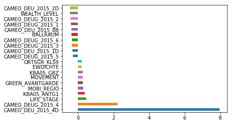

```python
plot_scaled_comparison(customers_cleaned_imputed_scaled, customer_kmeans_model, cluster_underrepresented)
```

**Observation:**

This cluster is dominated by people from the "Empty Nest" category, so elder people whose children have moved out. This makes sense, because from my point of view those people mostly don't spend a lot of money based on mail-order.

### Discussion 3.3: Compare Customer Data to Demographics Data

see my observations above, directly at the end of the over- and underrepresented clusters.

> Congratulations on making it this far in the project! Before you finish, make sure to check through the entire notebook from top to bottom to make sure that your analysis follows a logical flow and all of your findings are documented in **Discussion** cells. Once you've checked over all of your work, you should export the notebook as an HTML document to submit for evaluation. You can do this from the menu, navigating to **File -> Download as -> HTML (.html)**. You will submit both that document and this notebook for your project submission.